# Transgenic mice gene signature in human colon cancer

# we can also go one step further and look for all gene that were upregulated in mouse; aggregate these genes and determine if high expression can account for increase in survival with or without interactions.

- again here we split this into up and down genes.

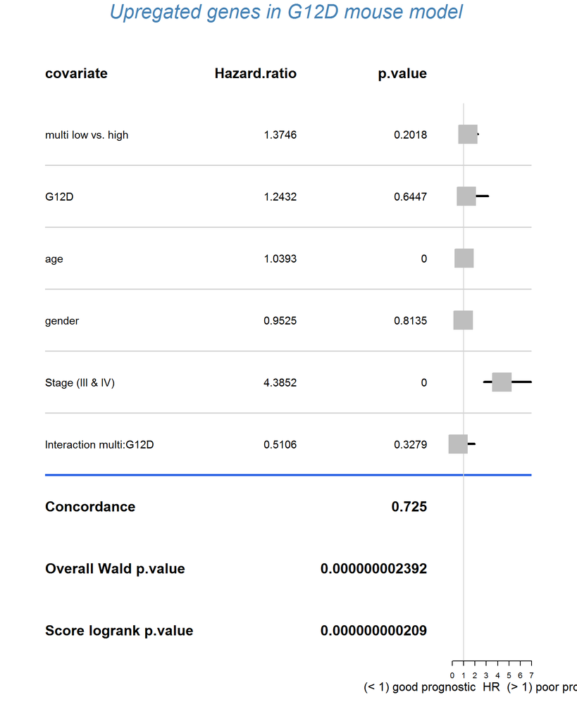

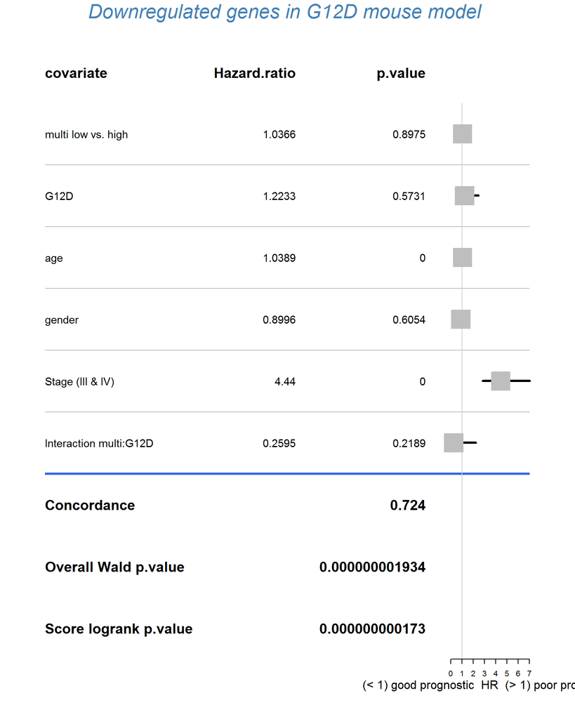

# Now we get into Human DGE. How does DGE G12D compare to WT look like in **humans**? What are the DGE? And how does supervised look like?